# Data Betas Lab 13

Brandon Nelsen. David Washburn, Burke Parent, Drew Hoffman, Tanner Ball

2019/11/24

```r
#Lab Tasks

#Each lab member should come up with and address a subquestion, and then each team should consolidate the findings and choose a single overall question that is most interesting.

#Each team member will be required to perform a permutation test so each team member should choose a subquestion that lends itself to being analyzed via a permutation test.

#Each team member will also be required to use at least one map function in their analysis from section 21.5 in R for Data Science. This does not have to be the main finding, but can be part of the exploratory analysis.

#Note that you may investigate other data sets if you feel that they pose more interesting questions. As long as you perform the above tasks in your analysis, any data sets from gapminder are okay to explore.
```

*Drew*

Do countries with higher life expectancy use more or less oil per capita than countries with a lower life expectancy?

Null hypothesis: There is no difference between oil consumption per capita based on life expectancy.

Alternative: There is a difference in oil consumption per capita based on a country’s life expectancy.

My test statistic is the difference in sample means of consumption per capita between two countries, one with higher life expectancy and one with lower. My higher life expectancy countries are Japan (82.603), Switzerland (81.701), and Canada (80.653). My lower expectancy countries are Trinidad and Tobago (69.819), South Africa (49.339), and Pakistan (65.483).

In two of the histogram results (Switzerland vs. South Africa and Canada vs. Pakistan) the real difference in sample means is in the 99th percentile of results. Therefore, I can reject the null hypothesis and can conclude that in countries with a higher life expectancy, they consume more oil per capita than in countries with lower life expectancy.

```r
perm_mean <- function(perms = 1000, all_values, n_A)
{
  ## Variables ##
  # perms: The number of permutations
  # all_values (num): all data values
  # n_A (int): Size of group A
  ###############

  # Step 1:
  # Create vector of zeroes of length "perms" to store
  # permuted mean differnces
  perm_mean_diffs <- numeric(perms)

  # Loop throught number of permutations
  for (i in c(1:perms))
  {
    # Step 2:
    # Randomly separate vector "values" into disjoint
    # groups of size "nA" and "nB" respectively
    rand_vector <- sample(all_values)
    group_a <- rand_vector[1:n_A]
    group_b <- rand_vector[(n_A+1):length(all_values)]

    # Step 3:
    # Compute the sample means for the two groups from
    # step 2
    mean_a <- mean(group_a)
    mean_b <- mean(group_b)

    # Step 4:
    # Compute the difference in sample means, store the
    # value in the vector from step 1
    diff_means <- mean_a - mean_b
    perm_mean_diffs[i] <- diff_means

  }

  # Step 5:
  # Return the permuted mean differences vector
  return(perm_mean_diffs)

}
```

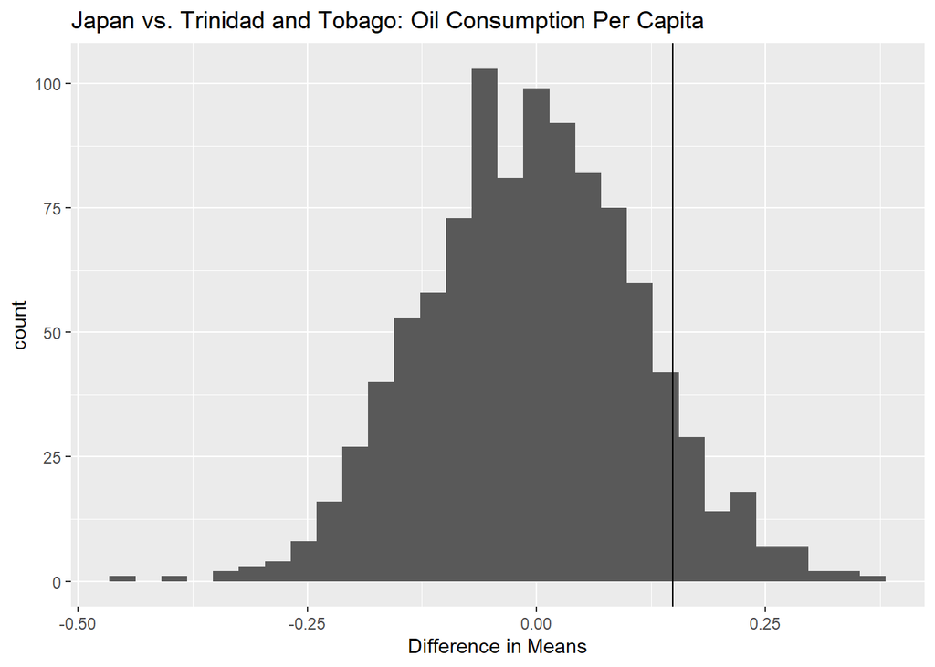

```r
oilPerCap <- read.csv("oil_consumption_per_cap.csv")
oilPerCap_noNA <- na.omit(oilPerCap)

#map function to calculate average yearly oil consumption by country
countryAverages <- map_dbl(oilPerCap_noNA, mean)
lifeExp <- gapminder %>%
  filter(year == 2007)
#I picked 3 countries from each category, high life expectancy and low life expectancy in 2007 and plotted them against each other
#High life exp: Japan, Switzerland, Canada
#Low life exp: Trinidad and Tobago, South Africa, Pakistan

#Japan vs Trinidad and Tobago
opc_1 <- oilPerCap_noNA[c(27,50),]
#Switzerland vs South Africa
opc_2 <- oilPerCap_noNA[c(48,44),]
#Canada vs Pakistan
opc_3 <- oilPerCap_noNA[c(8,34),]

#Unlists data values for perm tests
all1 <- unlist(opc_1)
all1 <- all1[3:106]
all2 <- unlist(opc_2)
all2 <- all2[3:106]
all3 <- unlist(opc_3)
all3 <- all3[3:106]

#running permutation test
rand1 <- perm_mean(1000, all1, 52)
rand2 <- perm_mean(1000, all2, 52)
rand3 <- perm_mean(1000, all3, 52)

#Getting real mean values for each country
jap <- oilPerCap_noNA[27,]
jap <- unlist(jap)
jap <- jap[2:53]
jap <- mean(jap)
swi <- oilPerCap_noNA[48,]
swi <- unlist(swi)
swi <- swi[2:53]
swi <- mean(swi)
can <- oilPerCap_noNA[8,]
can <- unlist(can)
can <- can[2:53]
can <- mean(can)
tri <- oilPerCap_noNA[50,]
tri <- unlist(tri)
tri <- tri[2:53]
tri <- mean(tri)
sou <- oilPerCap_noNA[44,]
sou <- unlist(sou)
sou <- sou[2:53]
sou <- mean(sou)
pak <- oilPerCap_noNA[34,]
pak <- unlist(pak)
pak <- pak[2:53]
pak <- mean(pak)

#calculating difference in means
diff1 <- jap - tri
diff2 <- swi - sou
diff3 <- can - pak

#plot of perm test vs difference in sample means
ggplot() + geom_histogram(aes(rand1)) +
  geom_vline(xintercept = diff1) +
  ggtitle("Japan vs. Trinidad and Tobago: Oil Consumption Per Capita") +
  xlab("Difference in Means")
```

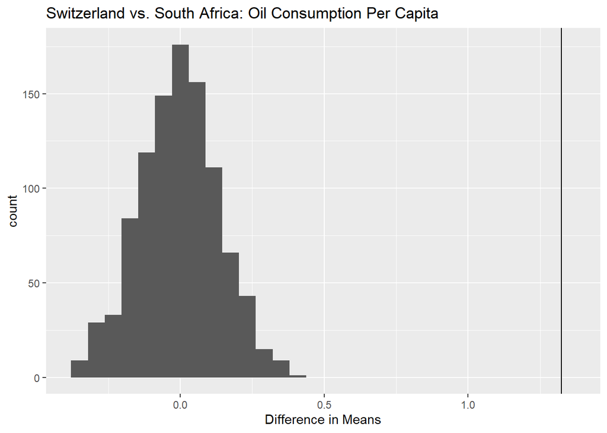

```r
ggplot() + geom_histogram(aes(rand2)) +
  geom_vline(xintercept = diff2) +
  ggtitle("Switzerland vs. South Africa: Oil Consumption Per Capita")  +
  xlab("Difference in Means")
```

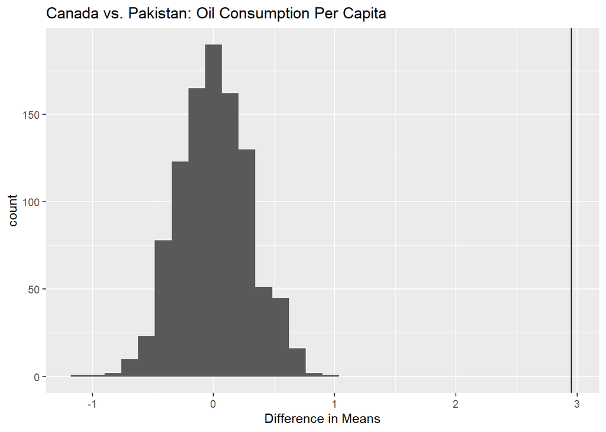

```r
ggplot() + geom_histogram(aes(rand3)) +
  geom_vline(xintercept = diff3) +
  ggtitle("Canada vs. Pakistan: Oil Consumption Per Capita")  +
  xlab("Difference in Means")
```

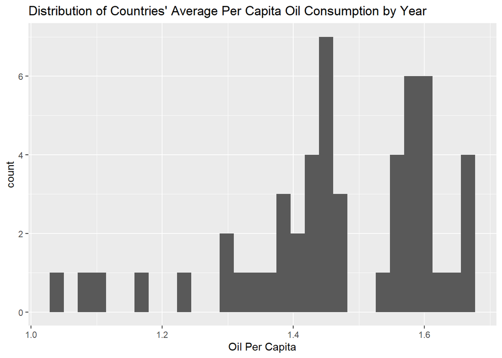

```r
ggplot() + geom_histogram(aes(countryAverages)) +
  ggtitle("Distribution of Countries' Average Per Capita Oil Consumption by Year") +
  xlab("Oil Per Capita")
```

*Burke*

How have northern european countries changed regarding generation of hydro power from 1960 to 2010 (In a 50 year period), and how does this change compare to changes in hydro power generation for countries of the United Kingdom and Ireland?

```r
hydro <- read.csv("hydro_power_generation_total.csv")
hydro <- na.omit(hydro)

#^I only want to use countries with complete data sets for each year.#

fifty <- hydro %>% select(country, X1960, X2010) %>% mutate(Diff = X2010 - X1960)
row_keep = c(FALSE, FALSE, FALSE, FALSE, TRUE, TRUE, FALSE, FALSE, FALSE, FALSE, TRUE, FALSE, FALSE, FALSE, FALSE, TRUE, FALSE, FALSE, FALSE, TRUE, FALSE, FALSE,TRUE, FALSE)
fifty = fifty[row_keep,]
colnames(fifty) <- c('Country', 1960, 2010, 'Diff')

#^Created a dataframe with relevant information from Denmark, Finland, Norway, Sweden, Ireland, and the United Kingdom.#

fifty
```

```
##           Country    1960     2010    Diff
## 5         Denmark    2150     1810    -340
## 6         Finland  453000  1110000  657000
## 11        Ireland   80100    51500  -28600
## 16         Norway 2690000 10100000 7410000
## 20         Sweden 2670000  5710000 3040000
## 23 United Kingdom  271000   310000   39000
```

```r
mean_nordic <- (-340 + 657000 + 7410000 + 3040000)/4
mean_UK_Ire <- (39000 + -28600)/2

#^Found mean of each region's hydro energy production.#

vec_fifty <- c("double", length = 1000)
for(i in seq_along(vec_fifty)){
  vec_fifty[i] <- (sample_n(fifty, 1) - sample_n(fifty, 1))
  sample
}
#Permutation Test for means to reject or prove null hypothesis.
```

*David*

How has employment rate changed from 1991 to 2015 for Asian countries? Answering this question can give us insight as to how employment has changed between generations. For this study, I will be analyzing the employment rate of Japan.

Null Hypothesis: Japan’s employment rate has not significantly changed compared to other Asian countries.

Japan’s change in employment rate from 1991 to 2015 is -4.6%, which is indicated by the red line in the histogram below. This value falls between the 5th and 95th percentile. Therefore we fail to reject the null hypothesis and conclude that Japan’s change in employment rate is not significant when compared to other countrys’ changes in employment rates.

```r
#read the data set and rename the years
employment.rate <- read.csv("aged_15plus_employment_rate_percent.csv")
colnames(employment.rate) <- c('Country', 1991:2022)

#tidy the data and select the years 1991 and 2015
employment.rate.9115 <- select(employment.rate, 'Country', 2, 26)
employment.rate.9115 <- gather(employment.rate.9115, `1991`, `2015`, key = 'year', value = 'eRate')

#filter by Asian Countries

employment.rate.9115.Asia <- filter(employment.rate.9115,
          Country == 'Afghanistan' | Country == 'Armenia' | Country == 'Azerbaijan' | Country == 'Bahrain' |
          Country == 'Bangladesh' | Country == 'Bhutan' | Country == 'Brunei' | Country == 'Cambodia' |
          Country == 'China' | Country == 'Cyprus' | Country == 'Georgia' | Country == 'India' |
          Country == 'Indonesia' | Country == 'Iran' | Country == 'Iraq' | Country == 'Israel' | Country == 'Japan' |
          Country == 'Jordan' | Country == 'Kazakhstan' | Country == 'Kuwait' | Country == 'Kyrgyzstan' |
          Country == 'Laos' | Country == 'Lebanon' | Country == 'Malaysia' | Country == 'Maldives' |
          Country == 'Mongolia' | Country == 'Myanmar' | Country == 'Nepal' | Country == 'North Korea' |
          Country == 'Oman' | Country == 'Pakistan' | Country == 'Palestine' | Country == 'Philippines' |
          Country == 'Qatar' | Country == 'Russia' | Country == 'Saudi Arabia' | Country == 'Singapore' |
          Country == 'South Korea' | Country == 'Sri Lanka' | Country == 'Syria' | Country == 'Taiwan' |
          Country == 'Tajikistan' | Country == 'Thailand' | Country == 'Timor-Leste' | Country == 'Turkey' |
          Country == 'Turkmenistan' | Country == 'United Arab Emirates' | Country == 'Uzbekistan' |
          Country == 'Vietnam' | Country == 'Yemen')

#first make a function that grabs a random 2015 value
  #get a data set consisting of employment rates from 2015
employment.rate.15.Asia <- filter(employment.rate.9115.Asia, year == 2015) %>% select(eRate)


#second make a function that grabs a random 1991 value
employment.rate.91.Asia <- filter(employment.rate.9115.Asia, year == 1991) %>% select(eRate)

#grab those values and subtract them in a loop

#now make a for loop with these functions

vector.9115 <- vector("double", length = 1000)
for(i in seq_along(vector.9115)){
  vector.9115[i] <- sample_n(employment.rate.15.Asia, 1)-sample_n(employment.rate.91.Asia, 1)
}

#make its a data frame
new.df<- unlist(vector.9115)

#get percentiles
quantile(new.df,c(.05, .95)) # -28.2 and 29.62 for 5th and 95th percentiles
```

```
##      5%     95%
## -28.405  27.820
```

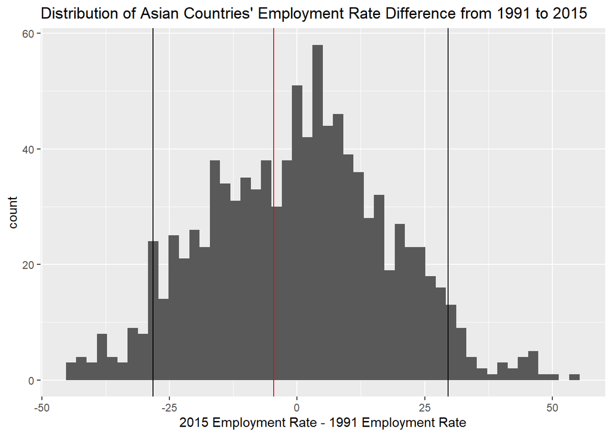

```r
#get japan data
  #2015: 58%, #1991:62.6%, difference = -4.6%

#histogram with relevent data

ggplot() + geom_histogram(aes(new.df), bins = 50)  +
  geom_vline(xintercept = -28.2) +
  geom_vline(xintercept = 29.62) +
  geom_vline(xintercept = -4.6, color = "red") +
  xlab("2015 Employment Rate - 1991 Employment Rate") +
  ggtitle("Distribution of Asian Countries' Employment Rate Difference from 1991 to 2015")
```

*Brandon*

How has total energy producton changed in South American countires from 1971 to 2008? This question is important because South America has been a greatly developing and changing continent since the 1970s and it can give us an idea about how South American countries will continue to develop. In this exploration I will be analyzing the total energy production in Chile.

Null Hypothesis: Chile’s total energy production has changed significantly compared to other South American Countries.

Null Hypothesis Rejection: Chile’s total energy production from 1971 to 2008 is within the 5% to 95% range meaning it did not siginificantly change compared to other South American Countries.

```
##      5%     95%
## -167300  219850
```

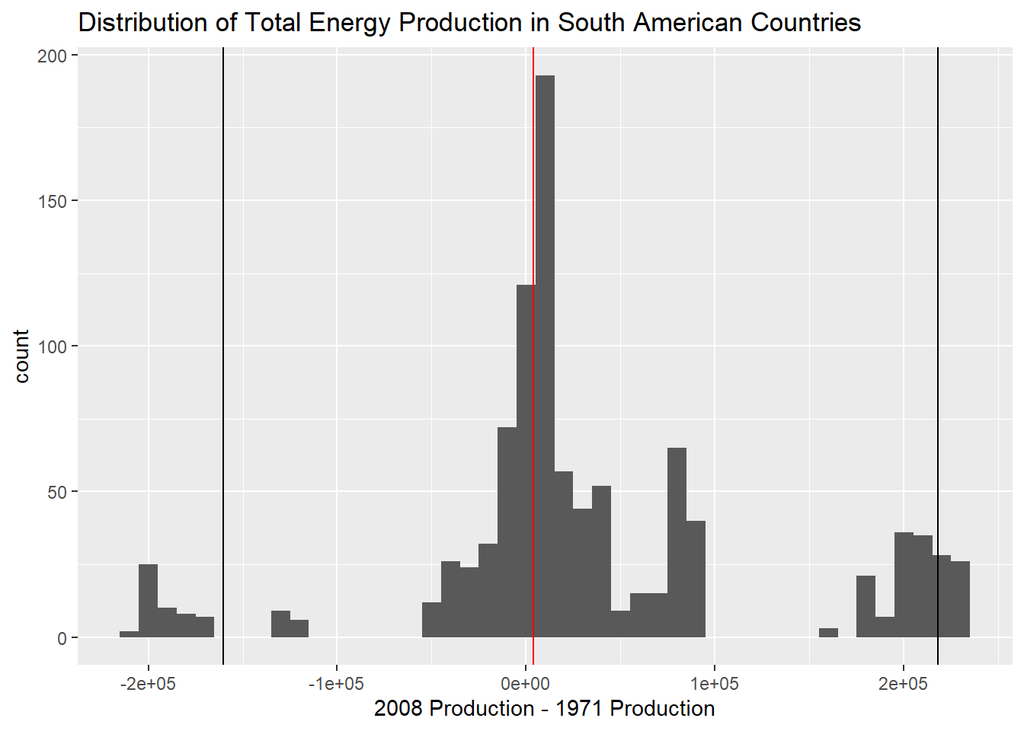

*Tanner*

How have CO2 emissions changed from 1952 to 2014 for the European Union and the United States? This question is important because we would like to see how the Western World has responded to the growing concern of climate change. Were they still increasing emissions in the near past, or have they been able to lower their emissions in response?

Null Hypothesis: There has not been a significant change in CO2 emissions for the United States from 1952 to 2014.

Null Rejection: The difference in emissions for the US from 1952 to 2014 falls well outside our 5% to 95% range on the positive extrema, indicating that the US has had quite a significant increase in CO2 emissions since 1952.

```r
# read in and clean up the dataset
co2 <- read_csv("yearly_co2_emissions_1000_tonnes.csv")
co2post1952 <- co2 %>% select(country, `1952`:`2014`)
co2noNA <- na.omit(co2post1952)

# filter out non-EU and US countries
CO2_EU_USA <- co2noNA %>% filter(country == "Austria" | country == "Belgium" | country == "Bulgaria" | country == "Croatia" | country == "Cyprus" | country == "Czech Republic" | country == "Denmark" | country == "Estonia" | country == "Finland" | country == "France" | country == "Germany" | country == "Greece" | country == "Hungary" | country == "Iceland" | country == "Italy" | country == "Latvia" | country == "Lithuania" | country == "Luxembourg" | country == "Malta" | country == "Netherlands" | country == "Poland" | country == "Portugal" | country == "Romania" | country == "Slovakia" | country == "Slovenia" | country == "Spain" | country == "Sweden" | country == "United Kingdom" | country == "United States")

# get our emissions for 1952 and 2014
CO2eu_usa2014 <- CO2_EU_USA %>% select(`2014`)
CO2eu_usa1952 <- CO2_EU_USA %>% select(`1952`)

# calculate real values for US for null hypothesis testing
usa1952 <- CO2eu_usa1952$`1952`[24]
usa2014 <- CO2eu_usa2014$`2014`[24]
usadiff <- usa2014 - usa1952 # 160675.25

# permutation test
vector.eu_usa <- vector("double", length = 1000)
for(i in seq_along(vector.eu_usa)){
  vector.eu_usa[i] <- (sample_n(CO2eu_usa2014, 1) - sample_n(CO2eu_usa1952, 1))
}

# Unlist the perm test vector and get our 5% and 95% values
UnlistedEU_USA <- unlist(vector.eu_usa)
quantile(UnlistedEU_USA, c(0.05,0.95)) # 5%: -599357, 95%: 693490 (these values will be used to define our 5% to 95% range)
```

```
##        5%       95%
## -564700.0  714646.5
```

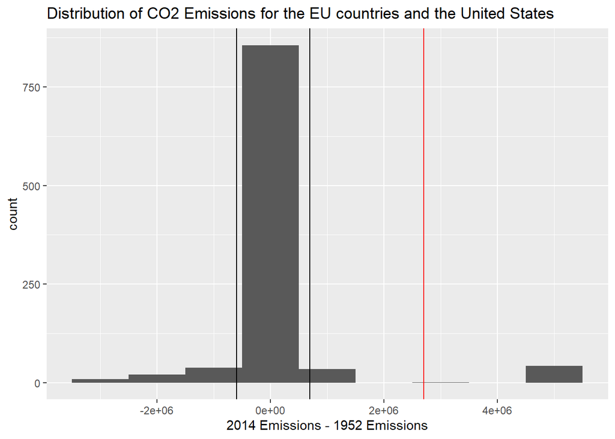

```r
ggplot()+
  geom_histogram(aes(UnlistedEU_USA), binwidth = 1000000)+
  geom_vline(xintercept = -599357) +
  geom_vline(xintercept = 693490) +
  geom_vline(xintercept = usadiff, color = "red") +
  ggtitle("Distribution of CO2 Emissions for the EU countries and the United States")+
  xlab("2014 Emissions - 1952 Emissions")
```